# Exploratory Data Analysis

Jose Caloca - 110558 & Marek Wrucha - 87195

23/05/2021

# Introduction.

In recent years, machine learning has become very important in the business world, as the intelligent use of data analytics is key to business success. For this project we will using the Bank Marketing Dataset from a portuguese bank, this dataset was originally uploaded to UCI’s Machine Learning Repository. This provides information on a marketing campaign that offers the results of contacts made offering time deposits from the financial institution in which it will be necessary to analyze and find future strategies to improve in future campaigns. A term deposit is a deposit offered by a bank or financial institution at a fixed rate (often better than simply opening a deposit account) in which your money will be returned to you at a specified time of maturity.

The aim of this project is to predict if the client will subscribe (yes/no) a term deposit (variable y), and to determine the factors behind a sucessful marketing campaign, and get a grasp of the features that influence on the probability of subscribing to a term deposit.

For this project we will be using R and Python at the same time in Rstudio - Rmarkdown.

## Data description.

### Load R packages and Python Modules

We will be using the following R packages and Python modules, we will load them as follows:

*- R Packages:*

```r
# load R libraries
if (!require(tidyverse)) install.packages("tidyverse", repos = "http://cran.us.r-project.org")
if (!require(DataExplorer)) install.packages("DataExplorer", repos = "http://cran.us.r-project.org")
if (!require(htmltools)) install.packages("htmltools", repos = "http://cran.us.r-project.org")
if (!require(ggstatsplot)) install.packages("ggstatsplot", repos = "http://cran.us.r-project.org")
if (!require(plotly)) install.packages("plotly", repos = "http://cran.us.r-project.org")
if (!require(rmdformats)) install.packages("rmdformats", repos = "http://cran.us.r-project.org")
```

*- Python Modules:*

```python
#load Python modules
import numpy as np
import pandas as pd
import matplotlib
import matplotlib.pyplot as plt
import sweetviz as sv
```

### Load dataset

The dataset used for this project can be found by clicking [*here*](https://archive.ics.uci.edu/ml/datasets/Bank+Marketing)*.* More specifically the dataset that we will load is the following: *bank-additional-full.csv*.

For loading the file we will call the *read_csv* function from pandas. It is it important to mention that there must be a folder called **dataset** in your main project folder that contains the aforementioned dataset. Or preferably it can be downloaded directly from the GitHub repository.

```python
#Import dataset
dataset = pd.read_csv("dataset/bank-additional-full.csv", sep = ";")
```

Before starting our analysis, we must recode the output variable to a binary class (1 and 0), instead of “yes” and “no” strings.

```python
dataset['y'] = dataset['y'].apply(lambda x: 0 if x =='no' else 1)
dataset.rename(columns = {"y" : "deposit"}, inplace = True)
```

The following chart shows a big picture of the dataset:

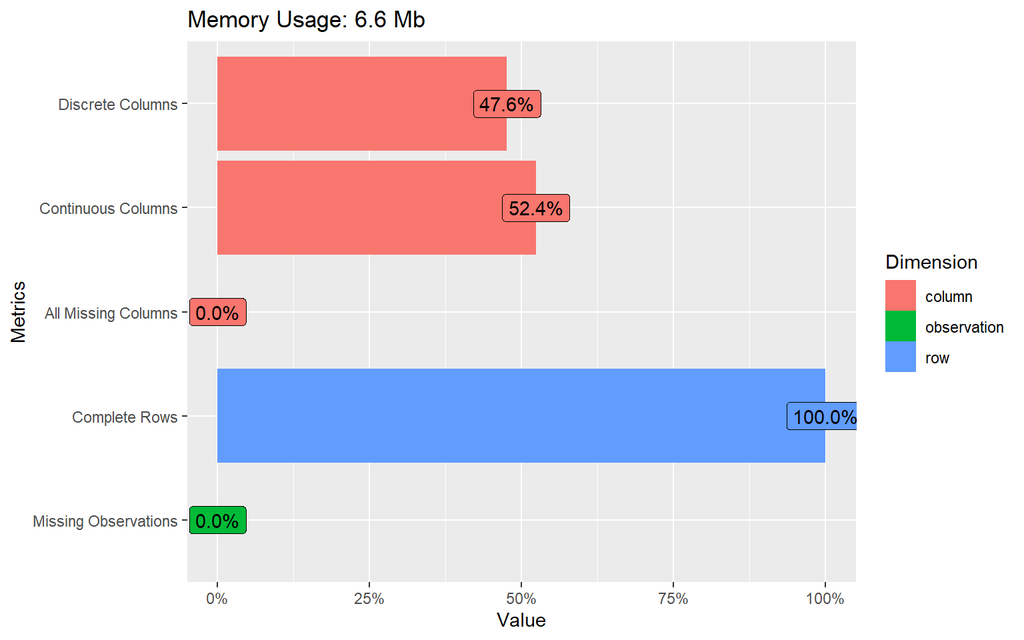

The dataset has 21 columns and 41188 rows. The variables have the following attributes:

$~$

#### Bank client data:

$~$

1. - age (numeric)

2. - job : type of job (categorical: ‘admin.’,‘blue-collar’,‘entrepreneur’,‘housemaid’,‘management’,‘retired’,‘self-employed’,‘services’,‘student’,‘technician’,‘unemployed’,‘unknown’)

3. - marital : marital status (categorical: ‘divorced’,‘married’,‘single’,‘unknown’; note: ‘divorced’ means divorced or widowed)

4. - education (categorical: ‘basic.4y’,‘basic.6y’,‘basic.9y’,‘high.school’,‘illiterate’,‘professional.course’,‘university.degree’,‘unknown’)

5. - default: has credit in default? (categorical: ‘no’,‘yes’,‘unknown’)

6. - housing: has housing loan? (categorical: ‘no’,‘yes’,‘unknown’)

7. - loan: has personal loan? (categorical: ‘no’,‘yes’,‘unknown’)

$~$

#### Data related with the last contact of the current campaign:

$~$

8. - contact: contact communication type (categorical: ‘cellular’,‘telephone’)

9. - month: last contact month of year (categorical: ‘jan’, ‘feb’, ‘mar’, …, ‘nov’, ‘dec’)

10. - day_of_week: last contact day of the week (categorical: ‘mon’,‘tue’,‘wed’,‘thu’,‘fri’)

11. - duration: last contact duration, in seconds (numeric). Important note: this attribute highly affects the output target (e.g., if duration=0 then y=‘no’). Yet, the duration is not known before a call is performed. Also, after the end of the call y is obviously known. Thus, this input should only be included for benchmark purposes and should be discarded if the intention is to have a realistic predictive model.

$~$

#### Other attributes:

$~$

12. - campaign: number of contacts performed during this campaign and for this client (numeric, includes last contact)

13. - pdays: number of days that passed by after the client was last contacted from a previous campaign (numeric; 999 means client was not previously contacted)

14. - previous: number of contacts performed before this campaign and for this client (numeric)

15. - poutcome: outcome of the previous marketing campaign (categorical: ‘failure’,‘nonexistent’,‘success’)

$~$

#### Social and economic context attributes

$~$

16. - emp.var.rate: employment variation rate - quarterly indicator (numeric)

17. - cons.price.idx: consumer price index - monthly indicator (numeric)

18. - cons.conf.idx: consumer confidence index - monthly indicator (numeric)

19. - euribor3m: euribor 3 month rate - daily indicator (numeric)

20. - nr.employed: number of employees - quarterly indicator (numeric)

$~$

#### Output variable (desired target):

$~$

21. - deposit - has the client subscribed a term deposit? (binary: ‘yes’,‘no’)

```python
dataset.info()
```

```
<class 'pandas.core.frame.DataFrame'>
RangeIndex: 41188 entries, 0 to 41187
Data columns (total 21 columns):
 #   Column          Non-Null Count  Dtype
---  ------          --------------  -----
 0   age             41188 non-null  int64
 1   job             41188 non-null  object
 2   marital         41188 non-null  object
 3   education       41188 non-null  object
 4   default         41188 non-null  object
 5   housing         41188 non-null  object
 6   loan            41188 non-null  object
 7   contact         41188 non-null  object
 8   month           41188 non-null  object
 9   day_of_week     41188 non-null  object
 10  duration        41188 non-null  int64
 11  campaign        41188 non-null  int64
 12  pdays           41188 non-null  int64
 13  previous        41188 non-null  int64
 14  poutcome        41188 non-null  object
 15  emp.var.rate    41188 non-null  float64
 16  cons.price.idx  41188 non-null  float64
 17  cons.conf.idx   41188 non-null  float64
 18  euribor3m       41188 non-null  float64
 19  nr.employed     41188 non-null  float64
 20  deposit         41188 non-null  int64
dtypes: float64(5), int64(6), object(10)
memory usage: 6.6+ MB
```

From the above description we can see that the variable *pdays* (number of days that passed by after the client was last contacted from a previous campaign), those customers that were not previously contacted had a value of 999. To this we are going to recode this variable for zeros (0).

```python
dataset['pdays'] = dataset['pdays'].apply(lambda x: 0 if x ==999 else x)
```

# Exploratory Data Analysis

The exploratory data analysis (EDA) or descriptive statistics is a preliminary and essential step when it comes to understanding the data with which we are going to work and highly recommended for a correct research methodology.

The objective of this analysis is to explore, describe, summarize and visualize the nature of the data collected in the random variables of the project or research of interest, through the application of simple data summary techniques and graphic methods without assuming assumptions for their interpretation.

For the creation of the EDA graphs we will be using the Python library **sweetviz**. Sweetviz is a library that generates nice-looking, high-density visualizations to kickstart EDA with just two lines of code. Output is a fully self-contained HTML application. The output is saved a HTML file in the project folder, and will be loaded to Rmarkdown to render by calling the function **includeHTML** from the **htmltools** package in R.

First, we look at some main summary statistics of our dataset and get a picture of the distribution of each variables.

```
      age                 job            marital
 Min.   :17.00   admin.     :10422   divorced: 4612
 1st Qu.:32.00   blue-collar: 9254   married :24928
 Median :38.00   technician : 6743   single  :11568
               education        default         housing           loan
 university.degree  :12168   no     :32588   no     :18622   no     :33950
 high.school        : 9515   unknown: 8597   unknown:  990   unknown:  990
 basic.9y           : 6045   yes    :    3   yes    :21576   yes    : 6248
      contact          month       day_of_week    duration
 cellular :26144   may    :13769   fri:7827    Min.   :   0.0
 telephone:15044   jul    : 7174   mon:8514    1st Qu.: 102.0
                   aug    : 6178   thu:8623    Median : 180.0
    campaign          pdays            previous            poutcome
 Min.   : 1.000   Min.   : 0.0000   Min.   :0.000   failure    : 4252
 1st Qu.: 1.000   1st Qu.: 0.0000   1st Qu.:0.000   nonexistent:35563
 Median : 2.000   Median : 0.0000   Median :0.000   success    : 1373
  emp.var.rate      cons.price.idx  cons.conf.idx     euribor3m
 Min.   :-3.40000   Min.   :92.20   Min.   :-50.8   Min.   :0.634
 1st Qu.:-1.80000   1st Qu.:93.08   1st Qu.:-42.7   1st Qu.:1.344
 Median : 1.10000   Median :93.75   Median :-41.8   Median :4.857
  nr.employed   deposit
 Min.   :4964   0:36548
 1st Qu.:5099   1: 4640
 Median :5191
 [ reached getOption("max.print") -- omitted 4 rows ]
```

32588 of the customers in the campaign haven’t default in previous financial services. A bit more than the half of the customers have their own house, and far more of them have an own phone. The ownership of a phone might be not relevant nowadays, but years ago this was an important issue.

In average, employees change their jobs around 8% per year in a deflationary context (average CPI of 93.58).

Regarding the visualisation part of our EDA, First we create the report and export it the project folder.

```python
#EDA using Autoviz
dataset_eda = sv.analyze(dataset)

#Saving results to HTML file
dataset_eda.show_html('Exploratory_Data_Analysis.html')
```

Second, we load the HTML file in the Rmarkdown notebook interface. We will go feature by feature in the following sections to see the range of values they have, how customers are distributed among these.

41188

ROWS

12

DUPLICATES

29.6 MB

RAM

21

FEATURES

13

CATEGORICAL

8

NUMERICAL

0

TEXT

1

age

VALUES:

41,188

(100%)

MISSING:

---

DISTINCT:

78

(<1%)

ZEROES:

---

MAX

98.0

95%

58.0

Q3

47.0

AVG

40.0

MEDIAN

38.0

Q1

32.0

5%

26.0

MIN

17.0

RANGE

81.0

IQR

15.0

STD

10.4

VAR

109

KURT.

0.791

SKEW

0.785

SUM

1.6M

2

job

VALUES:

41,188

(100%)

MISSING:

---

DISTINCT:

12

(<1%)

3

marital

VALUES:

41,188

(100%)

MISSING:

---

DISTINCT:

4

(<1%)

4

education

VALUES:

41,188

(100%)

MISSING:

---

DISTINCT:

8

(<1%)

5

default

VALUES:

41,188

(100%)

MISSING:

---

DISTINCT:

3

(<1%)

6

housing

VALUES:

41,188

(100%)

MISSING:

---

DISTINCT:

3

(<1%)

7

loan

VALUES:

41,188

(100%)

MISSING:

---

DISTINCT:

3

(<1%)

8

contact

VALUES:

41,188

(100%)

MISSING:

---

DISTINCT:

2

(<1%)

9

month

VALUES:

41,188

(100%)

MISSING:

---

DISTINCT:

10

(<1%)

10

day_of_week

VALUES:

41,188

(100%)

MISSING:

---

DISTINCT:

5

(<1%)

11

duration

VALUES:

41,188

(100%)

MISSING:

---

DISTINCT:

1,544

(4%)

ZEROES:

4

(<1%)

MAX

4,918

95%

753

Q3

319

AVG

258

MEDIAN

180

Q1

102

5%

36

MIN

0

RANGE

4,918

IQR

217

STD

259

VAR

67,226

KURT.

20.2

SKEW

3.26

SUM

10.6M

12

campaign

VALUES:

41,188

(100%)

MISSING:

---

DISTINCT:

42

(<1%)

ZEROES:

---

MAX

56.0

95%

7.0

Q3

3.0

AVG

2.6

MEDIAN

2.0

Q1

1.0

5%

1.0

MIN

1.0

RANGE

55.0

IQR

2.00

STD

2.77

VAR

7.67

KURT.

37.0

SKEW

4.76

SUM

106k

13

pdays

VALUES:

41,188

(100%)

MISSING:

---

DISTINCT:

26

(<1%)

ZEROES:

39,688

(96%)

MAX

27.0

95%

0.0

Q3

0.0

AVG

0.2

MEDIAN

0.0

Q1

0.0

5%

0.0

MIN

0.0

RANGE

27.0

IQR

0.00

STD

1.35

VAR

1.82

KURT.

76.4

SKEW

7.94

SUM

9,112

14

previous

VALUES:

41,188

(100%)

MISSING:

---

DISTINCT:

8

(<1%)

15

poutcome

VALUES:

41,188

(100%)

MISSING:

---

DISTINCT:

3

(<1%)

16

emp.var.rate

VALUES:

41,188

(100%)

MISSING:

---

DISTINCT:

10

(<1%)

17

cons.price.idx

VALUES:

41,188

(100%)

MISSING:

---

DISTINCT:

26

(<1%)

ZEROES:

---

MAX

94.77

95%

94.47

Q3

93.99

MEDIAN

93.75

AVG

93.58

Q1

93.08

5%

92.71

MIN

92.20

RANGE

2.57

IQR

0.919

STD

0.579

VAR

0.335

KURT.

-0.830

SKEW

-0.231

SUM

3.9M

18

cons.conf.idx

VALUES:

41,188

(100%)

MISSING:

---

DISTINCT:

26

(<1%)

ZEROES:

---

MAX

-26.9

95%

-33.6

Q3

-36.4

AVG

-40.5

MEDIAN

-41.8

Q1

-42.7

5%

-47.1

MIN

-50.8

RANGE

23.9

IQR

6.30

STD

4.63

VAR

21.4

KURT.

-0.359

SKEW

0.303

SUM

-1.7M

19

euribor3m

VALUES:

41,188

(100%)

MISSING:

---

DISTINCT:

316

(<1%)

ZEROES:

---

MAX

5.04

95%

4.97

Q3

4.96

MEDIAN

4.86

AVG

3.62

Q1

1.34

5%

0.80

MIN

0.63

RANGE

4.41

IQR

3.62

STD

1.73

VAR

3.01

KURT.

-1.41

SKEW

-0.709

SUM

149k

20

nr.employed

VALUES:

41,188

(100%)

MISSING:

---

DISTINCT:

11

(<1%)

ZEROES:

---

MAX

5,228

95%

5,228

Q3

5,228

MEDIAN

5,191

AVG

5,167

Q1

5,099

5%

5,018

MIN

4,964

RANGE

264

IQR

129

STD

72.3

VAR

5,220

KURT.

-0.004

SKEW

-1.04

SUM

212.8M

21

deposit

VALUES:

41,188

(100%)

MISSING:

---

DISTINCT:

2

(<1%)

Associations

age

MISSING:

---

>

NUMERICAL ASSOCIATIONS

(PEARSON, -1 to 1)

cons.conf.idx

0.13

pdays

0.02

nr.employed

-0.02

euribor3m

0.01

campaign

0.00

duration

-0.00

cons.price.idx

0.00

CATEGORICAL ASSOCIATIONS

(CORRELATION RATIO, 0 to 1)

job

0.50

marital

0.42

education

0.27

default

0.17

month

0.13

emp.var.rate

0.12

day_of_week

0.04

poutcome

0.04

previous

0.03

deposit

0.03

loan

0.01

contact

0.01

housing

0.00

31

1,947

4.7%

32

1,846

4.5%

33

1,833

4.5%

36

1,780

4.3%

35

1,759

4.3%

34

1,745

4.2%

30

1,714

4.2%

37

1,475

3.6%

29

1,453

3.5%

39

1,432

3.5%

38

1,407

3.4%

41

1,278

3.1%

40

1,161

2.8%

42

1,142

2.8%

45

1,103

2.7%

SMALLEST VALUES

17

5

<0.1%

18

28

<0.1%

19

42

0.1%

20

65

0.2%

21

102

0.2%

22

137

0.3%

23

226

0.5%

24

463

1.1%

25

598

1.5%

26

698

1.7%

27

851

2.1%

28

1,001

2.4%

29

1,453

3.5%

30

1,714

4.2%

31

1,947

4.7%

LARGEST VALUES

98

2

<0.1%

95

1

<0.1%

94

1

<0.1%

92

4

<0.1%

91

2

<0.1%

89

2

<0.1%

88

22

<0.1%

87

1

<0.1%

86

8

<0.1%

85

15

<0.1%

84

7

<0.1%

83

17

<0.1%

82

17

<0.1%

81

20

<0.1%

80

31

<0.1%

job

MISSING:

---

TOP CATEGORIES

admin.

10,422

25%

blue-collar

9,254

22%

technician

6,743

16%

services

3,969

10%

management

2,924

7%

retired

1,720

4%

entrepreneur

1,456

4%

self-employed

1,421

3%

housemaid

1,060

3%

unemployed

1,014

2%

student

875

2%

unknown

330

<1%

ALL

41,188

100%

CATEGORICAL ASSOCIATIONS  
(UNCERTAINTY COEFFICIENT, 0 to 1)

job  
PROVIDES INFORMATION ON...

education

0.23

marital

0.06

default

0.04

emp.var.rate

0.03

month

0.03

deposit

0.03

poutcome

0.02

previous

0.02

contact

0.01

loan

0.00

day_of_week

0.00

housing

0.00

THESE FEATURES  
GIVE INFORMATION  
ON job:

education

0.20

month

0.03

marital

0.02

emp.var.rate

0.02

default

0.01

deposit

0.00

poutcome

0.00

contact

0.00

previous

0.00

day_of_week

0.00

housing

0.00

loan

0.00

NUMERICAL ASSOCIATIONS  
(CORRELATION RATIO, 0 to 1)

job  
CORRELATION RATIO WITH...

age

0.50

nr.employed

0.23

euribor3m

0.19

cons.conf.idx

0.16

pdays

0.12

cons.price.idx

0.12

campaign

0.03

duration

0.03

marital

MISSING:

---

TOP CATEGORIES

married

24,928

61%

single

11,568

28%

divorced

4,612

11%

unknown

80

<1%

ALL

41,188

100%

CATEGORICAL ASSOCIATIONS  
(UNCERTAINTY COEFFICIENT, 0 to 1)

marital  
PROVIDES INFORMATION ON...

job

0.02

default

0.02

education

0.01

emp.var.rate

0.01

deposit

0.00

contact

0.00

previous

0.00

poutcome

0.00

month

0.00

housing

0.00

day_of_week

0.00

loan

0.00

THESE FEATURES  
GIVE INFORMATION  
ON marital:

job

0.06

education

0.02

default

0.01

emp.var.rate

0.01

month

0.00

contact

0.00

previous

0.00

deposit

0.00

poutcome

0.00

day_of_week

0.00

housing

0.00

loan

0.00

NUMERICAL ASSOCIATIONS  
(CORRELATION RATIO, 0 to 1)

marital  
CORRELATION RATIO WITH...

age

0.42

euribor3m

0.11

nr.employed

0.10

cons.price.idx

0.06

cons.conf.idx

0.06

pdays

0.04

campaign

0.01

duration

0.01

education

MISSING:

---

TOP CATEGORIES

university.degree

12,168

30%

high.school

9,515

23%

basic.9y

6,045

15%

professional.course

5,243

13%

basic.4y

4,176

10%

basic.6y

2,292

6%

unknown

1,731

4%

illiterate

18

<1%

ALL

41,188

100%

CATEGORICAL ASSOCIATIONS  
(UNCERTAINTY COEFFICIENT, 0 to 1)

education  
PROVIDES INFORMATION ON...

job

0.20

default

0.05

marital

0.02

month

0.02

contact

0.01

emp.var.rate

0.01

deposit

0.01

poutcome

0.00

previous

0.00

day_of_week

0.00

housing

0.00

loan

0.00

THESE FEATURES  
GIVE INFORMATION  
ON education:

job

0.23

month

0.02

default

0.02

marital

0.01

emp.var.rate

0.01

contact

0.00

deposit

0.00

poutcome

0.00

previous

0.00

day_of_week

0.00

housing

0.00

loan

0.00

NUMERICAL ASSOCIATIONS  
(CORRELATION RATIO, 0 to 1)

education  
CORRELATION RATIO WITH...

age

0.27

cons.conf.idx

0.12

cons.price.idx

0.10

nr.employed

0.06

euribor3m

0.05

pdays

0.05

duration

0.02

campaign

0.01

default

MISSING:

---

TOP CATEGORIES

no

32,588

79%

unknown

8,597

21%

yes

3

<1%

ALL

41,188

100%

CATEGORICAL ASSOCIATIONS  
(UNCERTAINTY COEFFICIENT, 0 to 1)

default  
PROVIDES INFORMATION ON...

emp.var.rate

0.02

deposit

0.02

education

0.02

poutcome

0.02

previous

0.01

contact

0.01

job

0.01

marital

0.01

month

0.01

housing

0.00

day_of_week

0.00

loan

0.00

THESE FEATURES  
GIVE INFORMATION  
ON default:

emp.var.rate

0.06

education

0.05

job

0.04

month

0.03

marital

0.02

contact

0.02

poutcome

0.01

previous

0.01

deposit

0.01

day_of_week

0.00

housing

0.00

loan

0.00

NUMERICAL ASSOCIATIONS  
(CORRELATION RATIO, 0 to 1)

default  
CORRELATION RATIO WITH...

euribor3m

0.20

nr.employed

0.19

cons.price.idx

0.17

age

0.17

pdays

0.07

campaign

0.03

cons.conf.idx

0.03

duration

0.01

housing

MISSING:

---

TOP CATEGORIES

yes

21,576

52%

no

18,622

45%

unknown

990

2%

ALL

41,188

100%

CATEGORICAL ASSOCIATIONS  
(UNCERTAINTY COEFFICIENT, 0 to 1)

housing  
PROVIDES INFORMATION ON...

loan

0.21

contact

0.01

emp.var.rate

0.00

month

0.00

previous

0.00

poutcome

0.00

default

0.00

education

0.00

deposit

0.00

day_of_week

0.00

job

0.00

marital

0.00

THESE FEATURES  
GIVE INFORMATION  
ON housing:

loan

0.15

contact

0.00

emp.var.rate

0.00

month

0.00

previous

0.00

job

0.00

education

0.00

poutcome

0.00

day_of_week

0.00

default

0.00

marital

0.00

deposit

0.00

NUMERICAL ASSOCIATIONS  
(CORRELATION RATIO, 0 to 1)

housing  
CORRELATION RATIO WITH...

cons.price.idx

0.08

euribor3m

0.06

nr.employed

0.05

cons.conf.idx

0.03

campaign

0.01

duration

0.01

pdays

0.00

age

0.00

loan

MISSING:

---

TOP CATEGORIES

no

33,950

82%

yes

6,248

15%

unknown

990

2%

ALL

41,188

100%

CATEGORICAL ASSOCIATIONS  
(UNCERTAINTY COEFFICIENT, 0 to 1)

loan  
PROVIDES INFORMATION ON...

housing

0.15

contact

0.00

month

0.00

emp.var.rate

0.00

previous

0.00

job

0.00

default

0.00

education

0.00

day_of_week

0.00

marital

0.00

poutcome

0.00

deposit

0.00

THESE FEATURES  
GIVE INFORMATION  
ON loan:

housing

0.21

month

0.00

emp.var.rate

0.00

job

0.00

contact

0.00

education

0.00

day_of_week

0.00

previous

0.00

default

0.00

marital

0.00

poutcome

0.00

deposit

0.00

NUMERICAL ASSOCIATIONS  
(CORRELATION RATIO, 0 to 1)

loan  
CORRELATION RATIO WITH...

cons.price.idx

0.02

cons.conf.idx

0.02

age

0.01

campaign

0.01

duration

0.00

nr.employed

0.00

pdays

0.00

euribor3m

0.00

contact

MISSING:

---

TOP CATEGORIES

cellular

26,144

63%

telephone

15,044

37%

ALL

41,188

100%

CATEGORICAL ASSOCIATIONS  
(UNCERTAINTY COEFFICIENT, 0 to 1)

contact  
PROVIDES INFORMATION ON...

emp.var.rate

0.17

month

0.11

poutcome

0.08

previous

0.07

deposit

0.03

default

0.02

housing

0.00

education

0.00

job

0.00

marital

0.00

day_of_week

0.00

loan

0.00

THESE FEATURES  
GIVE INFORMATION  
ON contact:

emp.var.rate

0.41

month

0.31

previous

0.06

poutcome

0.06

deposit

0.02

default

0.01

job

0.01

education

0.01

housing

0.01

marital

0.00

day_of_week

0.00

loan

0.00

NUMERICAL ASSOCIATIONS  
(CORRELATION RATIO, 0 to 1)

contact  
CORRELATION RATIO WITH...

cons.price.idx

0.59

euribor3m

0.40

nr.employed

0.27

cons.conf.idx

0.25

pdays

0.10

campaign

0.08

duration

0.03

age

0.01

month

MISSING:

---

TOP CATEGORIES

may

13,769

33%

jul

7,174

17%

aug

6,178

15%

jun

5,318

13%

nov

4,101

10%

apr

2,632

6%

oct

718

2%

sep

570

1%

mar

546

1%

dec

182

<1%

ALL

41,188

100%

CATEGORICAL ASSOCIATIONS  
(UNCERTAINTY COEFFICIENT, 0 to 1)

month  
PROVIDES INFORMATION ON...

emp.var.rate

0.69

contact

0.31

poutcome

0.10

previous

0.10

deposit

0.08

default

0.03

job

0.03

education

0.02

day_of_week

0.01

marital

0.00

housing

0.00

loan

0.00

THESE FEATURES  
GIVE INFORMATION  
ON month:

emp.var.rate

0.61

contact

0.11

job

0.03

poutcome

0.03

previous

0.03

education

0.02

deposit

0.01

default

0.01

day_of_week

0.01

marital

0.00

housing

0.00

loan

0.00

NUMERICAL ASSOCIATIONS  
(CORRELATION RATIO, 0 to 1)

month  
CORRELATION RATIO WITH...

nr.employed

0.65

cons.conf.idx

0.61

cons.price.idx

0.61

euribor3m

0.58

pdays

0.20

campaign

0.16

age

0.13

duration

0.07

day_of_week

MISSING:

---

TOP CATEGORIES

thu

8,623

21%

mon

8,514

21%

wed

8,134

20%

tue

8,090

20%

fri

7,827

19%

ALL

41,188

100%

CATEGORICAL ASSOCIATIONS  
(UNCERTAINTY COEFFICIENT, 0 to 1)

day_of_week  
PROVIDES INFORMATION ON...

month

0.01

emp.var.rate

0.00

contact

0.00

deposit

0.00

previous

0.00

poutcome

0.00

education

0.00

job

0.00

housing

0.00

default

0.00

marital

0.00

loan

0.00

THESE FEATURES  
GIVE INFORMATION  
ON day_of_week:

month

0.01

emp.var.rate

0.00

contact

0.00

education

0.00

job

0.00

previous

0.00

deposit

0.00

marital

0.00

housing

0.00

poutcome

0.00

default

0.00

loan

0.00

NUMERICAL ASSOCIATIONS  
(CORRELATION RATIO, 0 to 1)

day_of_week  
CORRELATION RATIO WITH...

cons.conf.idx

0.07

euribor3m

0.04

campaign

0.04

age

0.04

nr.employed

0.03

duration

0.03

cons.price.idx

0.02

pdays

0.01

duration

MISSING:

---

>

NUMERICAL ASSOCIATIONS

(PEARSON, -1 to 1)

campaign

-0.07

pdays

0.05

nr.employed

-0.04

euribor3m

-0.03

cons.conf.idx

-0.01

cons.price.idx

0.01

age

-0.00

CATEGORICAL ASSOCIATIONS

(CORRELATION RATIO, 0 to 1)

deposit

0.41

month

0.07

emp.var.rate

0.06

poutcome

0.05

day_of_week

0.03

job

0.03

previous

0.03

contact

0.03

education

0.02

marital

0.01

default

0.01

housing

0.01

loan

0.00

MOST FREQUENT VALUES

85

170

0.4%

90

170

0.4%

136

168

0.4%

73

167

0.4%

124

164

0.4%

87

162

0.4%

72

161

0.4%

104

161

0.4%

111

160

0.4%

106

159

0.4%

109

158

0.4%

97

158

0.4%

122

157

0.4%

135

156

0.4%

92

156

0.4%

SMALLEST VALUES

0

4

<0.1%

1

3

<0.1%

2

1

<0.1%

3

3

<0.1%

4

12

<0.1%

5

30

<0.1%

6

37

<0.1%

7

54

0.1%

8

69

0.2%

9

77

0.2%

10

72

0.2%

11

81

0.2%

12

65

0.2%

13

77

0.2%

14

70

0.2%

LARGEST VALUES

4918

1

<0.1%

4199

1

<0.1%

3785

1

<0.1%

3643

1

<0.1%

3631

1

<0.1%

3509

1

<0.1%

3422

1

<0.1%

3366

1

<0.1%

3322

1

<0.1%

3284

1

<0.1%

3253

1

<0.1%

3183

1

<0.1%

3094

1

<0.1%

3078

1

<0.1%

3076

1

<0.1%

campaign

MISSING:

---

>

NUMERICAL ASSOCIATIONS

(PEARSON, -1 to 1)

nr.employed

0.14

euribor3m

0.14

cons.price.idx

0.13

duration

-0.07

pdays

-0.04

cons.conf.idx

-0.01

age

0.00

CATEGORICAL ASSOCIATIONS

(CORRELATION RATIO, 0 to 1)

emp.var.rate

0.18

month

0.16

poutcome

0.09

previous

0.09

contact

0.08

deposit

0.07

day_of_week

0.04

default

0.03

job

0.03

marital

0.01

housing

0.01

education

0.01

loan

0.01

MOST FREQUENT VALUES

1

17,642

42.8%

2

10,570

25.7%

3

5,341

13.0%

4

2,651

6.4%

5

1,599

3.9%

6

979

2.4%

7

629

1.5%

8

400

1.0%

9

283

0.7%

10

225

0.5%

11

177

0.4%

12

125

0.3%

13

92

0.2%

14

69

0.2%

17

58

0.1%

SMALLEST VALUES

1

17,642

42.8%

2

10,570

25.7%

3

5,341

13.0%

4

2,651

6.4%

5

1,599

3.9%

6

979

2.4%

7

629

1.5%

8

400

1.0%

9

283

0.7%

10

225

0.5%

11

177

0.4%

12

125

0.3%

13

92

0.2%

14

69

0.2%

15

51

0.1%

LARGEST VALUES

56

1

<0.1%

43

2

<0.1%

42

2

<0.1%

41

1

<0.1%

40

2

<0.1%

39

1

<0.1%

37

1

<0.1%

35

5

<0.1%

34

3

<0.1%

33

4

<0.1%

32

4

<0.1%

31

7

<0.1%

30

7

<0.1%

29

10

<0.1%

28

8

<0.1%

pdays

MISSING:

---

>

NUMERICAL ASSOCIATIONS

(PEARSON, -1 to 1)

nr.employed

-0.32

euribor3m

-0.25

cons.conf.idx

0.06

duration

0.05

campaign

-0.04

cons.price.idx

-0.04

age

0.02

CATEGORICAL ASSOCIATIONS

(CORRELATION RATIO, 0 to 1)

poutcome

0.74

previous

0.50

emp.var.rate

0.37

deposit

0.27

month

0.20

job

0.12

contact

0.10

default

0.07

education

0.05

marital

0.04

day_of_week

0.01

housing

0.00

loan

0.00

MOST FREQUENT VALUES

0

39,688

96.4%

3

439

1.1%

6

412

1.0%

4

118

0.3%

9

64

0.2%

2

61

0.1%

7

60

0.1%

12

58

0.1%

10

52

0.1%

5

46

0.1%

13

36

<0.1%

11

28

<0.1%

1

26

<0.1%

15

24

<0.1%

14

20

<0.1%

SMALLEST VALUES

0

39,688

96.4%

1

26

<0.1%

2

61

0.1%

3

439

1.1%

4

118

0.3%

5

46

0.1%

6

412

1.0%

7

60

0.1%

8

18

<0.1%

9

64

0.2%

10

52

0.1%

11

28

<0.1%

12

58

0.1%

13

36

<0.1%

14

20

<0.1%

LARGEST VALUES

27

1

<0.1%

26

1

<0.1%

25

1

<0.1%

22

3

<0.1%

21

2

<0.1%

20

1

<0.1%

19

3

<0.1%

18

7

<0.1%

17

8

<0.1%

16

11

<0.1%

15

24

<0.1%

14

20

<0.1%

13

36

<0.1%

12

58

0.1%

11

28

<0.1%

previous

MISSING:

---

TOP CATEGORIES

0

35,563

86%

1

4,561

11%

2

754

2%

3

216

<1%

4

70

<1%

5

18

<1%

6

5

<1%

7

1

<1%

ALL

41,188

100%

CATEGORICAL ASSOCIATIONS  
(UNCERTAINTY COEFFICIENT, 0 to 1)

previous  
PROVIDES INFORMATION ON...

poutcome

0.85

emp.var.rate

0.10

contact

0.06

deposit

0.05

month

0.03

default

0.01

job

0.00

marital

0.00

education

0.00

housing

0.00

day_of_week

0.00

loan

0.00

THESE FEATURES  
GIVE INFORMATION  
ON previous:

poutcome

0.83

emp.var.rate

0.32

month

0.10

contact

0.07

deposit

0.04

job

0.02

default

0.01

education

0.00

marital

0.00

housing

0.00

day_of_week

0.00

loan

0.00

NUMERICAL ASSOCIATIONS  
(CORRELATION RATIO, 0 to 1)

previous  
CORRELATION RATIO WITH...

nr.employed

0.52

pdays

0.50

euribor3m

0.49

cons.price.idx

0.33

cons.conf.idx

0.14

campaign

0.09

age

0.03

duration

0.03

poutcome

MISSING:

---

TOP CATEGORIES

nonexistent

35,563

86%

failure

4,252

10%

success

1,373

3%

ALL

41,188

100%

CATEGORICAL ASSOCIATIONS  
(UNCERTAINTY COEFFICIENT, 0 to 1)

poutcome  
PROVIDES INFORMATION ON...

previous

0.83

emp.var.rate

0.10

deposit

0.09

contact

0.06

month

0.03

default

0.01

job

0.00

marital

0.00

education

0.00

housing

0.00

day_of_week

0.00

loan

0.00

THESE FEATURES  
GIVE INFORMATION  
ON poutcome:

previous

0.85

emp.var.rate

0.33

month

0.10

contact

0.08

deposit

0.06

job

0.02

default

0.02

education

0.00

marital

0.00

housing

0.00

day_of_week

0.00

loan

0.00

NUMERICAL ASSOCIATIONS  
(CORRELATION RATIO, 0 to 1)

poutcome  
CORRELATION RATIO WITH...

pdays

0.74

nr.employed

0.51

euribor3m

0.49

cons.price.idx

0.31

cons.conf.idx

0.18

campaign

0.09

duration

0.05

age

0.04

emp.var.rate

MISSING:

---

TOP CATEGORIES

1.4

16,234

39%

-1.8

9,184

22%

1.1

7,763

19%

-0.1

3,683

9%

-2.9

1,663

4%

-3.4

1,071

3%

-1.7

773

2%

-1.1

635

2%

-3.0

172

<1%

-0.2

10

<1%

ALL

41,188

100%

CATEGORICAL ASSOCIATIONS  
(UNCERTAINTY COEFFICIENT, 0 to 1)

emp.var.rate  
PROVIDES INFORMATION ON...

month

0.61

contact

0.41

poutcome

0.33

previous

0.32

deposit

0.16

default

0.06

job

0.02

education

0.01

marital

0.01

housing

0.00

day_of_week

0.00

loan

0.00

THESE FEATURES  
GIVE INFORMATION  
ON emp.var.rate:

month

0.69

contact

0.17

previous

0.10

poutcome

0.10

deposit

0.03

job

0.03

default

0.02

education

0.01

marital

0.01

day_of_week

0.00

housing

0.00

loan

0.00

NUMERICAL ASSOCIATIONS  
(CORRELATION RATIO, 0 to 1)

emp.var.rate  
CORRELATION RATIO WITH...

euribor3m

1.00

nr.employed

0.99

cons.price.idx

0.88

cons.conf.idx

0.83

pdays

0.37

campaign

0.18

age

0.12

duration

0.06

cons.price.idx

MISSING:

---

>

NUMERICAL ASSOCIATIONS

(PEARSON, -1 to 1)

euribor3m

0.69

nr.employed

0.52

campaign

0.13

cons.conf.idx

0.06

pdays

-0.04

duration

0.01

age

0.00

CATEGORICAL ASSOCIATIONS

(CORRELATION RATIO, 0 to 1)

emp.var.rate

0.88

month

0.61

contact

0.59

previous

0.33

poutcome

0.31

default

0.17

deposit

0.14

job

0.12

education

0.10

housing

0.08

marital

0.06

day_of_week

0.02

loan

0.02

MOST FREQUENT VALUES

93.994

7,763

18.8%

93.91799999999999

6,685

16.2%

92.89299999999999

5,794

14.1%

93.444

5,175

12.6%

94.465

4,374

10.6%

93.2

3,616

8.8%

93.075

2,458

6.0%

92.20100000000001

770

1.9%

92.963

715

1.7%

92.431

447

1.1%

92.649

357

0.9%

94.215

311

0.8%

94.199

303

0.7%

92.84299999999999

282

0.7%

92.37899999999999

267

0.6%

SMALLEST VALUES

92.20100000000001

770

1.9%

92.37899999999999

267

0.6%

92.431

447

1.1%

92.469

178

0.4%

92.649

357

0.9%

92.713

172

0.4%

92.756

10

<0.1%

92.84299999999999

282

0.7%

92.89299999999999

5,794

14.1%

92.963

715

1.7%

93.075

2,458

6.0%

93.2

3,616

8.8%

93.369

264

0.6%

93.444

5,175

12.6%

93.749

174

0.4%

LARGEST VALUES

94.76700000000001

128

0.3%

94.601

204

0.5%

94.465

4,374

10.6%

94.215

311

0.8%

94.199

303

0.7%

94.055

229

0.6%

94.027

233

0.6%

93.994

7,763

18.8%

93.91799999999999

6,685

16.2%

93.876

212

0.5%

93.79799999999999

67

0.2%

93.749

174

0.4%

93.444

5,175

12.6%

93.369

264

0.6%

93.2

3,616

8.8%

cons.conf.idx

MISSING:

---

>

NUMERICAL ASSOCIATIONS

(PEARSON, -1 to 1)

euribor3m

0.28

age

0.13

nr.employed

0.10

pdays

0.06

cons.price.idx

0.06

campaign

-0.01

duration

-0.01

CATEGORICAL ASSOCIATIONS

(CORRELATION RATIO, 0 to 1)

emp.var.rate

0.83

month

0.61

contact

0.25

poutcome

0.18

job

0.16

previous

0.14

education

0.12

day_of_week

0.07

marital

0.06

deposit

0.05

housing

0.03

default

0.03

loan

0.02

MOST FREQUENT VALUES

-36.4

7,763

18.8%

-42.7

6,685

16.2%

-46.2

5,794

14.1%

-36.1

5,175

12.6%

-41.8

4,374

10.6%

-42.0

3,616

8.8%

-47.1

2,458

6.0%

-31.4

770

1.9%

-40.8

715

1.7%

-26.9

447

1.1%

-30.1

357

0.9%

-40.3

311

0.8%

-37.5

303

0.7%

-50.0

282

0.7%

-29.8

267

0.6%

SMALLEST VALUES

-50.8

128

0.3%

-50.0

282

0.7%

-49.5

204

0.5%

-47.1

2,458

6.0%

-46.2

5,794

14.1%

-45.9

10

<0.1%

-42.7

6,685

16.2%

-42.0

3,616

8.8%

-41.8

4,374

10.6%

-40.8

715

1.7%

-40.4

67

0.2%

-40.3

311

0.8%

-40.0

212

0.5%

-39.8

229

0.6%

-38.3

233

0.6%

LARGEST VALUES

-26.9

447

1.1%

-29.8

267

0.6%

-30.1

357

0.9%

-31.4

770

1.9%

-33.0

172

0.4%

-33.6

178

0.4%

-34.6

174

0.4%

-34.8

264

0.6%

-36.1

5,175

12.6%

-36.4

7,763

18.8%

-37.5

303

0.7%

-38.3

233

0.6%

-39.8

229

0.6%

-40.0

212

0.5%

-40.3

311

0.8%

euribor3m

MISSING:

---

>

NUMERICAL ASSOCIATIONS

(PEARSON, -1 to 1)

nr.employed

0.95

cons.price.idx

0.69

cons.conf.idx

0.28

pdays

-0.25

campaign

0.14

duration

-0.03

age

0.01

CATEGORICAL ASSOCIATIONS

(CORRELATION RATIO, 0 to 1)

emp.var.rate

1.00

month

0.58

poutcome

0.49

previous

0.49

contact

0.40

deposit

0.31

default

0.20

job

0.19

marital

0.11

housing

0.06

education

0.05

day_of_week

0.04

loan

0.00

MOST FREQUENT VALUES

4.857

2,868

7.0%

4.962

2,613

6.3%

4.963

2,487

6.0%

4.961

1,902

4.6%

4.856

1,210

2.9%

4.9639999999999995

1,175

2.9%

1.405

1,169

2.8%

4.965

1,071

2.6%

4.864

1,044

2.5%

4.96

1,013

2.5%

4.968

992

2.4%

4.959

895

2.2%

4.86

892

2.2%

4.855

840

2.0%

4.0760000000000005

822

2.0%

SMALLEST VALUES

0.634

8

<0.1%

0.635

43

0.1%

0.636

14

<0.1%

0.637

6

<0.1%

0.638

7

<0.1%

0.639

16

<0.1%

0.64

10

<0.1%

0.642

35

<0.1%

0.643

23

<0.1%

0.644

38

<0.1%

0.645

26

<0.1%

0.6459999999999999

49

0.1%

0.649

10

<0.1%

0.65

12

<0.1%

0.6509999999999999

7

<0.1%

LARGEST VALUES

5.045

9

<0.1%

5.0

7

<0.1%

4.97

172

0.4%

4.968

992

2.4%

4.967

643

1.6%

4.966

622

1.5%

4.965

1,071

2.6%

4.9639999999999995

1,175

2.9%

4.963

2,487

6.0%

4.962

2,613

6.3%

4.961

1,902

4.6%

4.96

1,013

2.5%

4.959

895

2.2%

4.958

581

1.4%

4.957

537

1.3%

nr.employed

MISSING:

---

>

NUMERICAL ASSOCIATIONS

(PEARSON, -1 to 1)

euribor3m

0.95

cons.price.idx

0.52

pdays

-0.32

campaign

0.14

cons.conf.idx

0.10

duration

-0.04

age

-0.02

CATEGORICAL ASSOCIATIONS

(CORRELATION RATIO, 0 to 1)

emp.var.rate

0.99

month

0.65

previous

0.52

poutcome

0.51

deposit

0.35

contact

0.27

job

0.23

default

0.19

marital

0.10

education

0.06

housing

0.05

day_of_week

0.03

loan

0.00

MOST FREQUENT VALUES

5228.1

16,234

39.4%

5099.1

8,534

20.7%

5191.0

7,763

18.8%

5195.8

3,683

8.9%

5076.2

1,663

4.0%

5017.5

1,071

2.6%

4991.6

773

1.9%

5008.7

650

1.6%

4963.6

635

1.5%

5023.5

172

0.4%

5176.3

10

<0.1%

SMALLEST VALUES

4963.6

635

1.5%

4991.6

773

1.9%

5008.7

650

1.6%

5017.5

1,071

2.6%

5023.5

172

0.4%

5076.2

1,663

4.0%

5099.1

8,534

20.7%

5176.3

10

<0.1%

5191.0

7,763

18.8%

5195.8

3,683

8.9%

5228.1

16,234

39.4%

LARGEST VALUES

5228.1

16,234

39.4%

5195.8

3,683

8.9%

5191.0

7,763

18.8%

5176.3

10

<0.1%

5099.1

8,534

20.7%

5076.2

1,663

4.0%

5023.5

172

0.4%

5017.5

1,071

2.6%

5008.7

650

1.6%

4991.6

773

1.9%

4963.6

635

1.5%

deposit

MISSING:

---

TOP CATEGORIES

0

36,548

89%

1

4,640

11%

ALL

41,188

100%

CATEGORICAL ASSOCIATIONS  
(UNCERTAINTY COEFFICIENT, 0 to 1)

deposit  
PROVIDES INFORMATION ON...

poutcome

0.06

previous

0.04

emp.var.rate

0.03

contact

0.02

month

0.01

default

0.01

job

0.00

marital

0.00

education

0.00

day_of_week

0.00

housing

0.00

loan

0.00

THESE FEATURES  
GIVE INFORMATION  
ON deposit:

emp.var.rate

0.16

poutcome

0.09

month

0.08

previous

0.05

contact

0.03

job

0.03

default

0.02

education

0.01

marital

0.00

day_of_week

0.00

housing

0.00

loan

0.00

NUMERICAL ASSOCIATIONS  
(CORRELATION RATIO, 0 to 1)

deposit  
CORRELATION RATIO WITH...

duration

0.41

nr.employed

0.35

euribor3m

0.31

pdays

0.27

cons.price.idx

0.14

campaign

0.07

cons.conf.idx

0.05

age

0.03

$~$

$~$

$~$

$~$

$~$

$~$

$~$

$~$

$~$

$~$

$~$

$~$

$~$

$~$

$~$

$~$

$~$

$~$

$~$

$~$

$~$

$~$

$~$

$~$

$~$

$~$

$~$

$~$

$~$

$~$

$~$

$~$

$~$

$~$

$~$

$~$

$~$

$~$

$~$

$~$

$~$

$~$

$~$

$~$

$~$

$~$

$~$

$~$

$~$

$~$

$~$

$~$

$~$

$~$

$~$

$~$

$~$

$~$

$~$

$~$

$~$

$~$

$~$

$~$

$~$

$~$

$~$

$~$

$~$

$~$

$~$

$~$

$~$

$~$

$~$

$~$

$~$

$~$

$~$

$~$

$~$

$~$

$~$

$~$

$~$

## EDA analysis:

From the target variable, we can see that 88.73 % of the customers haven’t subscribed to the financial product offered, therefore we have an imbalanced dataset. This situation will be refectled in the train, validation and test sets when modelling. For that we will use either the undersampling or oversampling techniques.

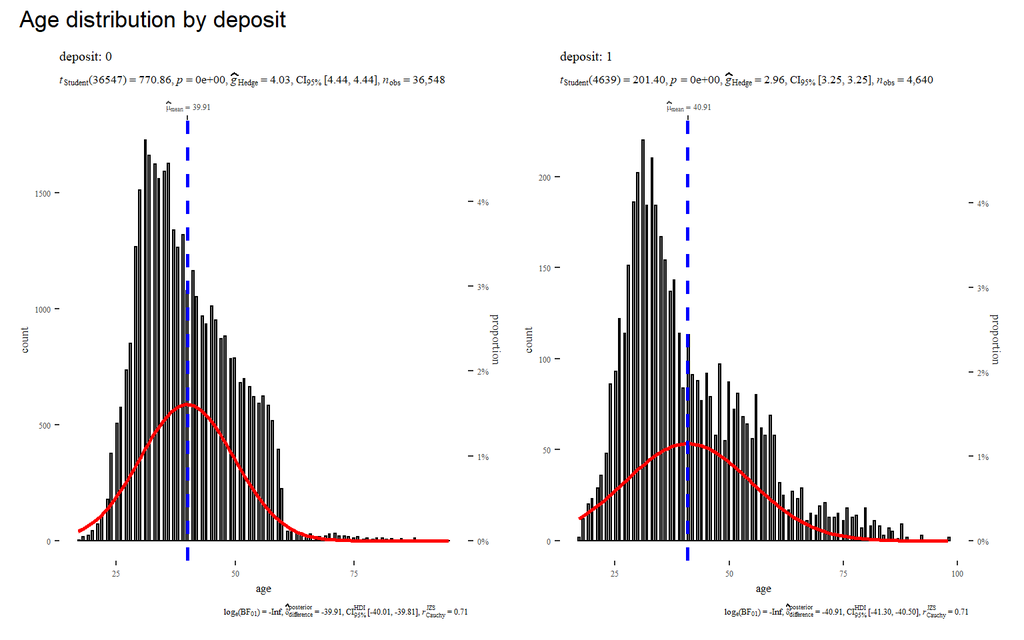

```r
grouped_gghistostats(
    data = dataset,
    x = age,
    grouping.var = deposit, # grouping variable
    normal.curve = TRUE, # superimpose a normal distribution curve
    normal.curve.args = list(color = "red", size = 1),
    ggtheme = ggthemes::theme_tufte(),
    plotgrid.args = list(nrow = 1),
    ggstatsplot.layer = FALSE,
    ggplot.component = list(theme(text = element_text(size = 6.3))),
    annotation.args = list(title = "Age distribution by deposit")
)
```

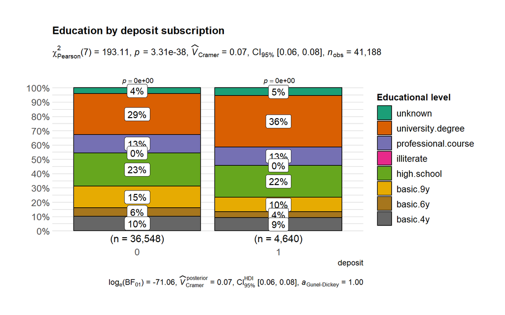

```r
ggbarstats(data = dataset, x = education, y = deposit, title = "Education by deposit subscription",
    legend.title = "Educational level", ggtheme = hrbrthemes::theme_ipsum_pub())
```

Education shows a difference between the different levels. For example, some types of clients present an efficiency of 13.72% (university students) while those with basic levels of studies do not reach 9% in some cases. We could say that we should aim to offer this product to clients who have college, professional or high school levels.

In the case of type of work, retirees, students, unemployed and management positions are those who lead with the best results to offer the financial product.

Regarding marital status, we could infer that single clients are a bit more sensitive to acquire the offer of term deposits.

The month variable is a good indicator. Note that the number of contacts and their efficiency varies strongly from month to month. For example, in March we obtained 50% efficiency with very few contacts made (only 500), however, in May 14 thousand contacts were made with only an efficiency of 6.4%

Regarding the variable pdays we can say that most of the clients were contacted for the first time.

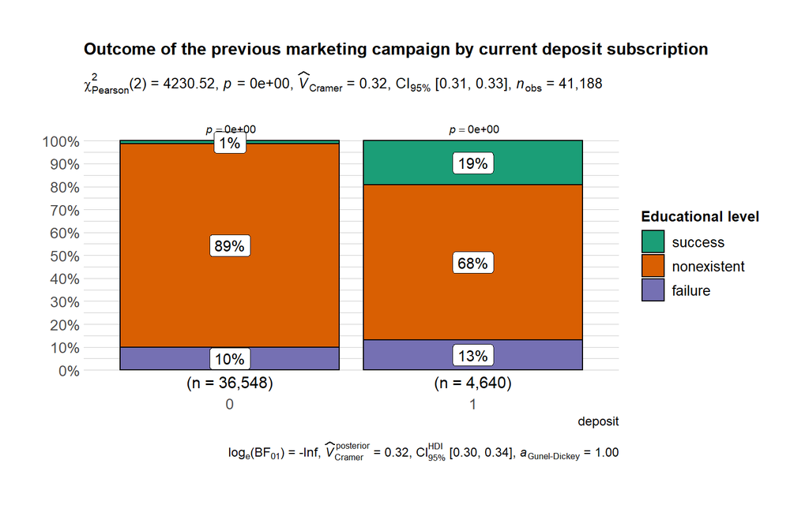

```r
ggbarstats(data = dataset, x = poutcome, y = deposit, title = "Outcome of the previous marketing campaign by current deposit subscription",
    legend.title = "Educational level", ggtheme = hrbrthemes::theme_ipsum_pub())
```

Out of the people that subscribed for a deposit, only 19% of these customers had a previous deposit (sucessfull result) in the previous campaign.

As for the next section regarding the data pre-processing there is no need to impute the data since we don’t have missing values, regarding the outliers, we can see few outliers in the variable “age” and we will accept them since there are no regulations regarding the age of a customer to subscribe to a term deposit. If this case study would be credit-risk related, then we would have to discard these outliers or manipulate them.